# Healthcare Analysis

Gao

2024-02-28

```r
library(tidymodels)
library(tidyverse)
```

```r
library(rpart.plot)
library(caret)
library(dplyr)
```

1-5.

```r
Watson <- read_csv("Watson_Healthcare_Modified.csv")
```

6. Convert the Attrition column from the character type to the factor type. This is necessary because the dependent variable in a classification model must be of the factor type.

```r
Watson$Attrition <- as.factor(Watson$Attrition)
```

7. Drop all columns of the character type that only have a single unique value. This is necessary because having an independent variable that only has a single unique values causes an error if you attempt to tune a classification model.

I chose these three variables by looking at the tibble in the environment pane

```r
Watson <- select(Watson,-c(EmployeeCount, Over18, StandardHours))
```

8. Split the data into testing and training sets

I used a 75-25 split

```r
Watson_split <- initial_split(Watson, prop = 0.75)

train <- training(Watson_split)

test <- testing(Watson_split)
```

9. Create a decision tree model with a depth of 30 and a minimum of 5 data points per node

```r
dtree_mod <- decision_tree(mode = "classification", min_n = 5, tree_depth = 30)
```

10. Fit the model to predict the Attrition variable given all of the remaining variables in the data set.

```r
dtree_mod_fit <- fit(object = dtree_mod, formula = Attrition ~ ., data = train)
```

11. Plot the model.

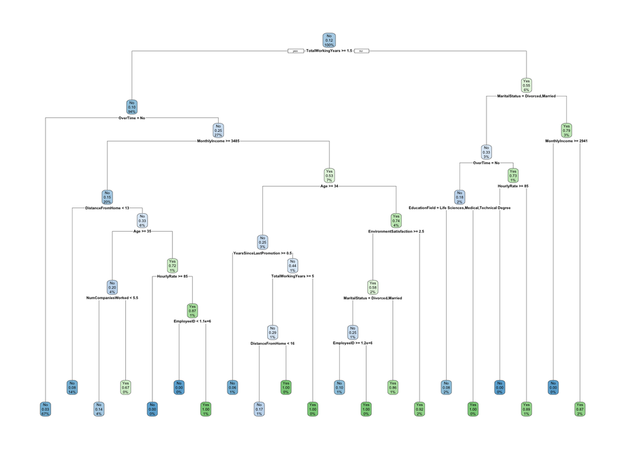

```r
dtree_mod_fit %>% extract_fit_engine() %>% rpart.plot()
```

12. Create the predictions for the model.

```r
predictions <- predict(dtree_mod_fit, new_data = test)

predictions
```

```
## # A tibble: 419 × 1
##    .pred_class
##    <fct>
##  1 No
##  2 No
##  3 Yes
##  4 Yes
##  5 No
##  6 No
##  7 Yes
##  8 No
##  9 No
## 10 No
## # ℹ 409 more rows
```

13. View the confusion matrix for the model as well as the accuracy and kappa metrics.

```r
confusionMatrix(data = predictions$.pred_class, reference = test$Attrition)
```

```
## Confusion Matrix and Statistics
##
##           Reference
## Prediction  No Yes
##        No  353  25
##        Yes  20  21
##
##                Accuracy : 0.8926
##                  95% CI : (0.8589, 0.9206)
##     No Information Rate : 0.8902
##     P-Value [Acc > NIR] : 0.4769
##
##                   Kappa : 0.4231
##
##  Mcnemar's Test P-Value : 0.5510
##
##             Sensitivity : 0.9464
##             Specificity : 0.4565
##          Pos Pred Value : 0.9339
##          Neg Pred Value : 0.5122
##              Prevalence : 0.8902
##          Detection Rate : 0.8425
##    Detection Prevalence : 0.9021
##       Balanced Accuracy : 0.7015
##
##        'Positive' Class : No
##
```

14. Check the variable importance of the model. Make a note of any variables that have an importance of 0.

```r
dtree_mod_fit %>% extract_fit_engine() %>% varImp()
```

```
##                            Overall
## Age                      79.437351
## BusinessTravel            2.782625
## DailyRate                 8.531197
## Department                8.080026
## DistanceFromHome         19.701149
## EducationField           16.616032
## EmployeeID               16.687287
## EnvironmentSatisfaction  33.267342
## Gender                    5.224603
## HourlyRate               15.968860
## JobInvolvement           10.967100
## JobLevel                 25.110249
## JobRole                   1.388889
## JobSatisfaction           1.363636
## MaritalStatus            27.629377
## MonthlyIncome            58.354816
## MonthlyRate               8.072619
## NumCompaniesWorked       11.512984
## OverTime                 59.510247
## RelationshipSatisfaction  1.784314
## Shift                    24.419984
## TotalWorkingYears        54.615063
## TrainingTimesLastYear     4.407647
## WorkLifeBalance           1.280303
## YearsAtCompany           19.075530
## YearsInCurrentRole        2.347222
## YearsSinceLastPromotion   2.722222
## Education                 0.000000
## PercentSalaryHike         0.000000
## PerformanceRating         0.000000
## YearsWithCurrManager      0.000000
```

15. Create six cross validation folds for the training data

```r
folds <- vfold_cv(train, v = 6)
```

16. Create an automatic grid of hyperparameters for the model

```r
tree_grid_auto <- grid_regular(tree_depth(), min_n(), cost_complexity())

tree_grid_auto
```

```
## # A tibble: 27 × 3
##    tree_depth min_n cost_complexity
##         <int> <int>           <dbl>
##  1          1     2    0.0000000001
##  2          8     2    0.0000000001
##  3         15     2    0.0000000001
##  4          1    21    0.0000000001
##  5          8    21    0.0000000001
##  6         15    21    0.0000000001
##  7          1    40    0.0000000001
##  8          8    40    0.0000000001
##  9         15    40    0.0000000001
## 10          1     2    0.00000316
## # ℹ 17 more rows
```

```r
print(tree_grid_auto, n = 27)
```

```
## # A tibble: 27 × 3
##    tree_depth min_n cost_complexity
##         <int> <int>           <dbl>
##  1          1     2    0.0000000001
##  2          8     2    0.0000000001
##  3         15     2    0.0000000001
##  4          1    21    0.0000000001
##  5          8    21    0.0000000001
##  6         15    21    0.0000000001
##  7          1    40    0.0000000001
##  8          8    40    0.0000000001
##  9         15    40    0.0000000001
## 10          1     2    0.00000316
## 11          8     2    0.00000316
## 12         15     2    0.00000316
## 13          1    21    0.00000316
## 14          8    21    0.00000316
## 15         15    21    0.00000316
## 16          1    40    0.00000316
## 17          8    40    0.00000316
## 18         15    40    0.00000316
## 19          1     2    0.1
## 20          8     2    0.1
## 21         15     2    0.1
## 22          1    21    0.1
## 23          8    21    0.1
## 24         15    21    0.1
## 25          1    40    0.1
## 26          8    40    0.1
## 27         15    40    0.1
```

17. Use the grid and the folds to tune the model

```r
dtree_mod_tune <- decision_tree(mode = "classification", tree_depth = tune(), min_n = tune(), cost_complexity = tune())

tuning_data <- tune_grid(dtree_mod_tune, preprocessor = Attrition ~., resamples = folds, grid = tree_grid_auto)

print(tuning_data %>% collect_metrics, n = 54)
```

```
## # A tibble: 54 × 9
##    cost_complexity tree_depth min_n .metric  .estimator  mean     n std_err
##              <dbl>      <int> <int> <chr>    <chr>      <dbl> <int>   <dbl>
##  1    0.0000000001          1     2 accuracy binary     0.876     6 0.00979
##  2    0.0000000001          1     2 roc_auc  binary     0.521     6 0.0152
##  3    0.0000000001          8     2 accuracy binary     0.875     6 0.00708
##  4    0.0000000001          8     2 roc_auc  binary     0.744     6 0.0382
##  5    0.0000000001         15     2 accuracy binary     0.868     6 0.00590
##  6    0.0000000001         15     2 roc_auc  binary     0.727     6 0.0237
##  7    0.0000000001          1    21 accuracy binary     0.876     6 0.00979
##  8    0.0000000001          1    21 roc_auc  binary     0.521     6 0.0152
##  9    0.0000000001          8    21 accuracy binary     0.881     6 0.00932
## 10    0.0000000001          8    21 roc_auc  binary     0.841     6 0.0176
## 11    0.0000000001         15    21 accuracy binary     0.881     6 0.00932
## 12    0.0000000001         15    21 roc_auc  binary     0.841     6 0.0176
```

[output cut: 43 more lines]

18. Display the best hyperparameter values for the model

The best hyperparameter values are min_n = 40, and tree_depth = 8

```r
tuning_data %>% select_best(metric = "accuracy")
```

```
## # A tibble: 1 × 4
##   cost_complexity tree_depth min_n .config
##             <dbl>      <int> <int> <chr>
## 1    0.0000000001          8    40 Preprocessor1_Model08
```

```r
tuning_data %>% show_best(metric = "accuracy")
```

```
## # A tibble: 5 × 9
##   cost_complexity tree_depth min_n .metric  .estimator  mean     n std_err
##             <dbl>      <int> <int> <chr>    <chr>      <dbl> <int>   <dbl>
## 1    0.0000000001          8    40 accuracy binary     0.902     6 0.00827
## 2    0.0000000001         15    40 accuracy binary     0.902     6 0.00827
## 3    0.00000316            8    40 accuracy binary     0.902     6 0.00827
## 4    0.00000316           15    40 accuracy binary     0.902     6 0.00827
## 5    0.0000000001          8    21 accuracy binary     0.881     6 0.00932
## # ℹ 1 more variable: .config <chr>
```

19. Create the final model that uses the best hyperparameter values.

```r
dtree_mod_final <- decision_tree(mode = "classification", min_n = 40, tree_depth = 8)
```

```r
dtree_mod_fit_final <- fit(object = dtree_mod, formula = Attrition ~ . - Education - PerformanceRating - RelationshipSatisfaction - TrainingTimesLastYear, data = train)
```

21. Use the final mode to create predictions.

```r
predictions_final <- predict(dtree_mod_fit_final, new_data = test)

predictions_final
```

```
## # A tibble: 419 × 1
##    .pred_class
##    <fct>
##  1 No
##  2 No
##  3 Yes
##  4 Yes
##  5 No
##  6 No
##  7 Yes
##  8 No
##  9 No
## 10 No
## # ℹ 409 more rows
```

22. View the confusion matrix for the final model

```r
confusionMatrix(data = predictions_final$.pred_class, reference = test$Attrition)
```

```
## Confusion Matrix and Statistics
##
##           Reference
## Prediction  No Yes
##        No  353  25
##        Yes  20  21
##
##                Accuracy : 0.8926
##                  95% CI : (0.8589, 0.9206)
##     No Information Rate : 0.8902
##     P-Value [Acc > NIR] : 0.4769
##
##                   Kappa : 0.4231
##
##  Mcnemar's Test P-Value : 0.5510
##
##             Sensitivity : 0.9464
##             Specificity : 0.4565
##          Pos Pred Value : 0.9339
##          Neg Pred Value : 0.5122
##              Prevalence : 0.8902
##          Detection Rate : 0.8425
##    Detection Prevalence : 0.9021
##       Balanced Accuracy : 0.7015
##
##        'Positive' Class : No
##
```